# McDonalds-Solution by Shubhank

```python
#Importing all important libraries and packages:

import os
import numpy as np
import pandas as pd
import seaborn as sns
import matplotlib.pyplot as plt
%matplotlib inline
```

```python
#Checking the current working directory.

os.getcwd()
```

```
'C:\\Users\\user'
```

```python
#Changing the working directory where the 'McDonald.csv' file is stored.

os.chdir('D:\\SHUBHANK !\\GL\\3. TOPIC 2 - Statistical Methods for Decision Making\\SMDM- Week 2')
```

```python
#Again checking the directory after changing it.

os.getcwd()
```

```
'D:\\SHUBHANK !\\GL\\3. TOPIC 2 - Statistical Methods for Decision Making\\SMDM- Week 2'
```

## Now opening and reading the data from the McDonald.csv file:

```python
McData = pd.read_csv('Mcdonald.csv')
```

## Now fetching and displaying the top 10 records from the file:

```python
McData.head(10)
```

|  | Category | Item | Serving Size | Calories | Calories from Fat | Total Fat | Total Fat (% Daily Value) | Saturated Fat | Saturated Fat (% Daily Value) | Trans Fat | ... | Carbohydrates | Carbohydrates (% Daily Value) | Dietary Fiber | Dietary Fiber (% Daily Value) | Sugars | Protein | Vitamin A (% Daily Value) | Vitamin C (% Daily Value) | Calcium (% Daily Value) | Iron (% Daily Value) |
| --- | --- | --- | --- | --- | --- | --- | --- | --- | --- | --- | --- | --- | --- | --- | --- | --- | --- | --- | --- | --- | --- |
| 0 | Breakfast | Egg McMuffin | 4.8 oz (136 g) | 300 | 120 | 13.0 | 20 | 5.0 | 25 | 0.0 | ... | 31 | 10 | 4 | 17 | 3 | 17 | 10 | 0 | 25 | 15 |
| 1 | Breakfast | Egg White Delight | 4.8 oz (135 g) | 250 | 70 | 8.0 | 12 | 3.0 | 15 | 0.0 | ... | 30 | 10 | 4 | 17 | 3 | 18 | 6 | 0 | 25 | 8 |
| 2 | Breakfast | Sausage McMuffin | 3.9 oz (111 g) | 370 | 200 | 23.0 | 35 | 8.0 | 42 | 0.0 | ... | 29 | 10 | 4 | 17 | 2 | 14 | 8 | 0 | 25 | 10 |
| 3 | Breakfast | Sausage McMuffin with Egg | 5.7 oz (161 g) | 450 | 250 | 28.0 | 43 | 10.0 | 52 | 0.0 | ... | 30 | 10 | 4 | 17 | 2 | 21 | 15 | 0 | 30 | 15 |
| 4 | Breakfast | Sausage McMuffin with Egg Whites | 5.7 oz (161 g) | 400 | 210 | 23.0 | 35 | 8.0 | 42 | 0.0 | ... | 30 | 10 | 4 | 17 | 2 | 21 | 6 | 0 | 25 | 10 |
| 5 | Breakfast | Steak & Egg McMuffin | 6.5 oz (185 g) | 430 | 210 | 23.0 | 36 | 9.0 | 46 | 1.0 | ... | 31 | 10 | 4 | 18 | 3 | 26 | 15 | 2 | 30 | 20 |
| 6 | Breakfast | Bacon, Egg & Cheese Biscuit (Regular Biscuit) | 5.3 oz (150 g) | 460 | 230 | 26.0 | 40 | 13.0 | 65 | 0.0 | ... | 38 | 13 | 2 | 7 | 3 | 19 | 10 | 8 | 15 | 15 |
| 7 | Breakfast | Bacon, Egg & Cheese Biscuit (Large Biscuit) | 5.8 oz (164 g) | 520 | 270 | 30.0 | 47 | 14.0 | 68 | 0.0 | ... | 43 | 14 | 3 | 12 | 4 | 19 | 15 | 8 | 20 | 20 |
| 8 | Breakfast | Bacon, Egg & Cheese Biscuit with Egg Whites (R... | 5.4 oz (153 g) | 410 | 180 | 20.0 | 32 | 11.0 | 56 | 0.0 | ... | 36 | 12 | 2 | 7 | 3 | 20 | 2 | 8 | 15 | 10 |
| 9 | Breakfast | Bacon, Egg & Cheese Biscuit with Egg Whites (L... | 5.9 oz (167 g) | 470 | 220 | 25.0 | 38 | 12.0 | 59 | 0.0 | ... | 42 | 14 | 3 | 12 | 4 | 20 | 6 | 8 | 15 | 15 |

10 rows × 24 columns

```python
#to describe the five number summary and some other important numerical information about the dataset:

McData.describe()
```

|  | Calories | Calories from Fat | Total Fat | Total Fat (% Daily Value) | Saturated Fat | Saturated Fat (% Daily Value) | Trans Fat | Cholesterol | Cholesterol (% Daily Value) | Sodium | ... | Carbohydrates | Carbohydrates (% Daily Value) | Dietary Fiber | Dietary Fiber (% Daily Value) | Sugars | Protein | Vitamin A (% Daily Value) | Vitamin C (% Daily Value) | Calcium (% Daily Value) | Iron (% Daily Value) |
| --- | --- | --- | --- | --- | --- | --- | --- | --- | --- | --- | --- | --- | --- | --- | --- | --- | --- | --- | --- | --- | --- |
| count | 260.000000 | 260.000000 | 260.000000 | 260.000000 | 260.000000 | 260.000000 | 260.000000 | 260.000000 | 260.000000 | 260.000000 | ... | 260.000000 | 260.000000 | 260.000000 | 260.000000 | 260.000000 | 260.000000 | 260.000000 | 260.000000 | 260.000000 | 260.000000 |
| mean | 368.269231 | 127.096154 | 14.165385 | 21.815385 | 6.007692 | 29.965385 | 0.203846 | 54.942308 | 18.392308 | 495.750000 | ... | 47.346154 | 15.780769 | 1.630769 | 6.530769 | 29.423077 | 13.338462 | 13.426923 | 8.534615 | 20.973077 | 7.734615 |
| std | 240.269886 | 127.875914 | 14.205998 | 21.885199 | 5.321873 | 26.639209 | 0.429133 | 87.269257 | 29.091653 | 577.026323 | ... | 28.252232 | 9.419544 | 1.567717 | 6.307057 | 28.679797 | 11.426146 | 24.366381 | 26.345542 | 17.019953 | 8.723263 |
| min | 0.000000 | 0.000000 | 0.000000 | 0.000000 | 0.000000 | 0.000000 | 0.000000 | 0.000000 | 0.000000 | 0.000000 | ... | 0.000000 | 0.000000 | 0.000000 | 0.000000 | 0.000000 | 0.000000 | 0.000000 | 0.000000 | 0.000000 | 0.000000 |
| 25% | 210.000000 | 20.000000 | 2.375000 | 3.750000 | 1.000000 | 4.750000 | 0.000000 | 5.000000 | 2.000000 | 107.500000 | ... | 30.000000 | 10.000000 | 0.000000 | 0.000000 | 5.750000 | 4.000000 | 2.000000 | 0.000000 | 6.000000 | 0.000000 |
| 50% | 340.000000 | 100.000000 | 11.000000 | 17.000000 | 5.000000 | 24.000000 | 0.000000 | 35.000000 | 11.000000 | 190.000000 | ... | 44.000000 | 15.000000 | 1.000000 | 5.000000 | 17.500000 | 12.000000 | 8.000000 | 0.000000 | 20.000000 | 4.000000 |
| 75% | 500.000000 | 200.000000 | 22.250000 | 35.000000 | 10.000000 | 48.000000 | 0.000000 | 65.000000 | 21.250000 | 865.000000 | ... | 60.000000 | 20.000000 | 3.000000 | 10.000000 | 48.000000 | 19.000000 | 15.000000 | 4.000000 | 30.000000 | 15.000000 |
| max | 1880.000000 | 1060.000000 | 118.000000 | 182.000000 | 20.000000 | 102.000000 | 2.500000 | 575.000000 | 192.000000 | 3600.000000 | ... | 141.000000 | 47.000000 | 7.000000 | 28.000000 | 128.000000 | 87.000000 | 170.000000 | 240.000000 | 70.000000 | 40.000000 |

8 rows × 21 columns

```python
#getting the basic info of the dataset like about datatype, about missing values, total entries, etc..

McData.info()
```

```
<class 'pandas.core.frame.DataFrame'>
RangeIndex: 260 entries, 0 to 259
Data columns (total 24 columns):
 #   Column                         Non-Null Count  Dtype
---  ------                         --------------  -----
 0   Category                       260 non-null    object
 1   Item                           260 non-null    object
 2   Serving Size                   260 non-null    object
 3   Calories                       260 non-null    int64
 4   Calories from Fat              260 non-null    int64
 5   Total Fat                      260 non-null    float64
 6   Total Fat (% Daily Value)      260 non-null    int64
 7   Saturated Fat                  260 non-null    float64
 8   Saturated Fat (% Daily Value)  260 non-null    int64
 9   Trans Fat                      260 non-null    float64
```

[output cut: 16 more lines]

## Q1. Plot graphically which food categories have the highest and lowest varieties.

### Solution: The below countplot will display the food categories with hignest and lowest varieties:

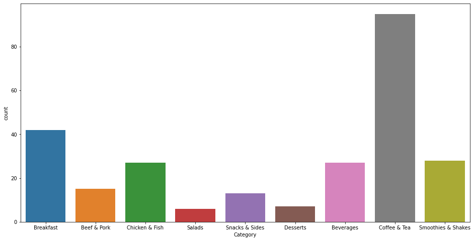

```python
plt.figure(figsize=(16,8))             #defining the figure size of the plot
sns.countplot(McData['Category']);
```

### So, from the above plot we can see that 'Coffee & Tea' have the most varities and 'Salads' have the least varities.

## Q2. Which all variables have an outlier ?

### Solution: We can check the outliers only for the columns with Numerical data.

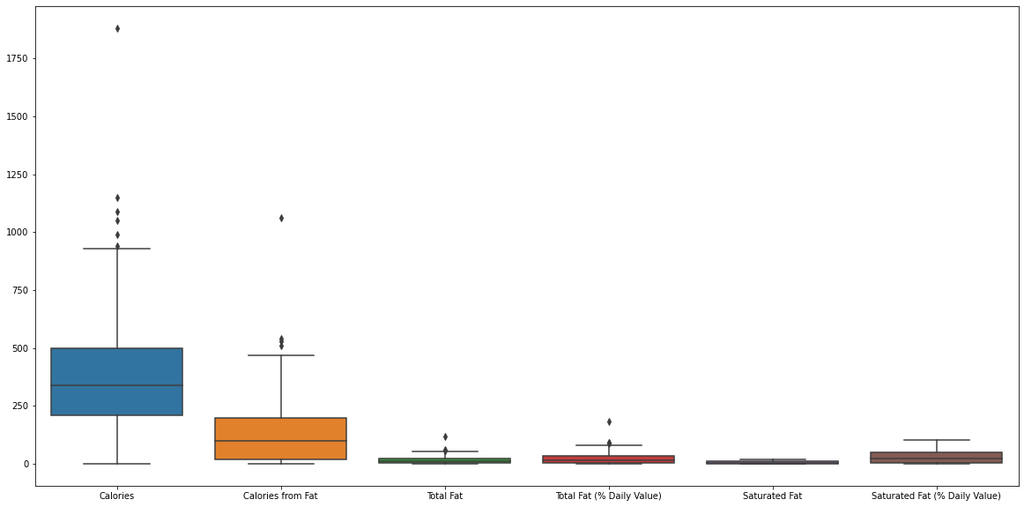

```python
#Showing the boxplot and checking the outliers for the below variables:
#'Calories','Calories from Fat','Total Fat','Total Fat (% Daily Value)','Saturated Fat','Saturated Fat (% Daily Value).


plt.figure(figsize=(20,10))

sns.boxplot(data = McData[['Calories','Calories from Fat','Total Fat','Total Fat (% Daily Value)','Saturated Fat'
                           ,'Saturated Fat (% Daily Value)']]);
```

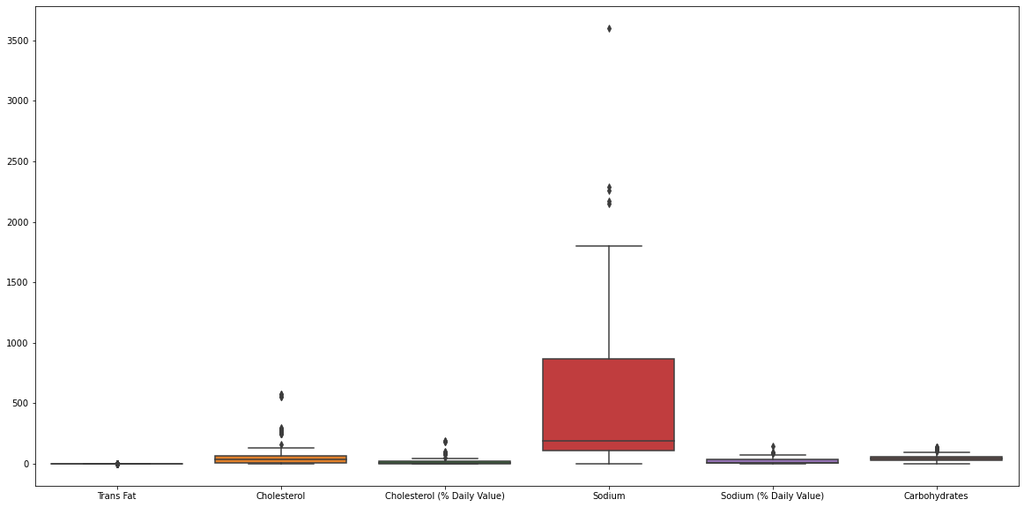

```python
#Showing the boxplot and checking the outliers for the below variables:
#'Trans Fat','Cholesterol','Cholesterol (% Daily Value)','Sodium','Sodium (% Daily Value)','Carbohydrates.


plt.figure(figsize=(20,10))

sns.boxplot(data = McData[['Trans Fat','Cholesterol','Cholesterol (% Daily Value)','Sodium','Sodium (% Daily Value)'
                           ,'Carbohydrates']]);
```

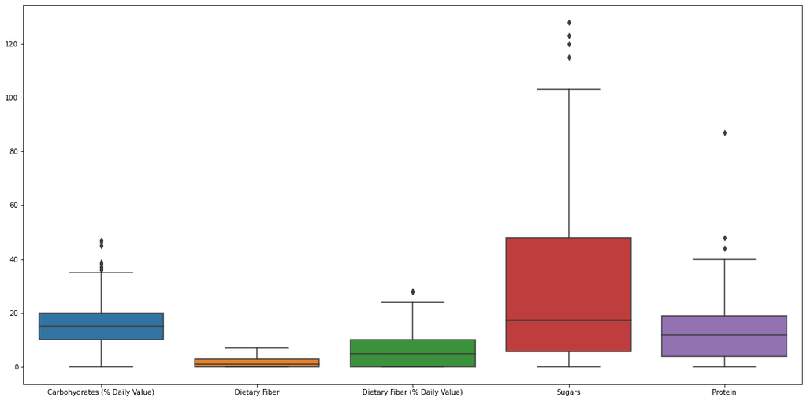

```python
#Showing the boxplot and checking the outliers for the below variables:
#'Carbohydrates (% Daily Value)','Dietary Fiber','Dietary Fiber (% Daily Value)','Sugars','Protein.

plt.figure(figsize=(20,10))

sns.boxplot(data = McData[['Carbohydrates (% Daily Value)','Dietary Fiber','Dietary Fiber (% Daily Value)','Sugars'
                           ,'Protein']]);
```

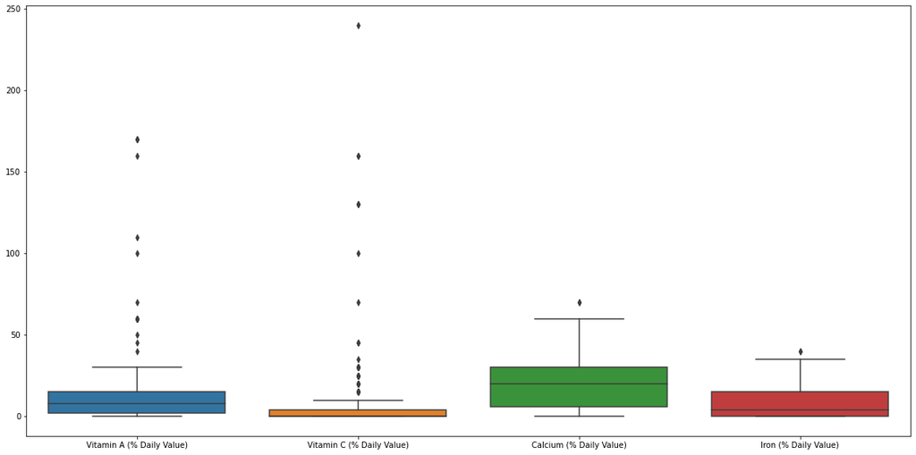

```python
#Showing the boxplot and checking the outliers for the below variables:
#Vitamin A (% Daily Value),Vitamin C (% Daily Value),Calcium (% Daily Value),Iron (% Daily Value)

plt.figure(figsize=(20,10))

sns.boxplot(data = McData[['Vitamin A (% Daily Value)','Vitamin C (% Daily Value)','Calcium (% Daily Value)',
                           'Iron (% Daily Value)']]);
```

## So, from the above boxplots we can conclude that:

## The variables with outliers are :-

### *Cholestrol

### *Cholestrol (% Daily Value)

### *Calories from Fat

### *Cholestrol

### *Cholestrol (% Daily Value)

### *Total Fat

### *Total Fat (% Daily Value)

### *Sodium

### *Sodium (% Daily Value)

## The variables which don't have outliers are :-

### *Saturated Fat

### *Dietary Fiber

## Q3. Which variables have the highest correlation? Plot them and find out the value?

## Solution: First we will create the correlation matrices between the variables:

```python
corr = McData.corr()

corr
```

[output not shown]

21 rows × 21 columns

[figure not shown]

```python
#Now we will plot the heatmap to display the correlation between the variables:

fig, ax = plt.subplots(figsize=(17,17))
sns.heatmap(corr,annot=True)
```

## and so on..

## Q4. Which category contributes to the maximum % of Cholesterol in a diet (% daily value)?

### Solution: First we will count the total Unique Categories in the dataset and then will solve the given question.

```python
McData['Category'].nunique()
```

```
9
```

```python
Required_result_1 = pd.pivot_table(McData, 'Cholesterol (% Daily Value)', index=['Category'])

print('\n \n The list of different categories with their respective % Cholesterol is:-\n\n', Required_result_1)
```

```
 The list of different categories with their respective % Cholesterol is:-

                     Cholesterol (% Daily Value)
Category
Beef & Pork                           28.933333
Beverages                              0.185185
Breakfast                             50.952381
Chicken & Fish                        25.222222
Coffee & Tea                           9.378947
Desserts                               4.857143
Salads                                17.333333
Smoothies & Shakes                    14.714286
Snacks & Sides                         6.230769
```

### So, from the above information we can see that the 'Breakfast' category contributes to the maximum % of Cholesterol in a diet.

## Q5. Which item contributes maximum to the Sodium intake ?

### Solution: First we will check the total Items present in the dataset:

```python
McData['Item'].nunique()
```

```
260
```

## Now we will create the pivot table for the columns 'Sodium' and 'Item' :

```python
P_table = pd.pivot_table(McData, 'Sodium', index=['Item'])

P_table
```

| Item | Sodium |
| --- | --- |
| 1% Low Fat Milk Jug | 125 |
| Apple Slices | 0 |
| Bacon Buffalo Ranch McChicken | 1260 |
| Bacon Cheddar McChicken | 1260 |
| Bacon Clubhouse Burger | 1470 |
| ... | ... |
| Sweet Tea (Medium) | 10 |
| Sweet Tea (Small) | 10 |
| Vanilla Shake (Large) | 260 |
| Vanilla Shake (Medium) | 200 |
| Vanilla Shake (Small) | 160 |

260 rows × 1 columns

## Now we need to sort the data in the descending order of the sodium values so that we can find out the item that contributes maximum to the sodium intake:

```python
Required_result_2 = P_table.sort_values(('Sodium'), ascending=False)

Required_result_2
```

| Item | Sodium |
| --- | --- |
| Chicken McNuggets (40 piece) | 3600 |
| Big Breakfast with Hotcakes and Egg Whites (Large Biscuit) | 2290 |
| Big Breakfast with Hotcakes (Large Biscuit) | 2260 |
| Big Breakfast with Hotcakes and Egg Whites (Regular Biscuit) | 2170 |
| Big Breakfast with Hotcakes (Regular Biscuit) | 2150 |
| ... | ... |
| Coca-Cola Classic (Child) | 0 |
| Dasani Water Bottle | 0 |
| Minute Maid Orange Juice (Medium) | 0 |
| Apple Slices | 0 |
| Minute Maid Orange Juice (Small) | 0 |

260 rows × 1 columns

### So from the above result we can see the item 'Chicken McNuggets' contributes maximum to the Sodium intake.

## Q6. Which 4 food items contains the most amount of Saturated Fat ?

### Solution: We will create the pivot table between the columns 'Saturated fat' and 'Items' and then we will sort the table to get the top 4 food items contains the most amount of Saturated Fat :

```python
P_table_1 = pd.pivot_table(McData, 'Saturated Fat', index=['Item'])


Required_result_3 = P_table_1.sort_values(('Saturated Fat'), ascending=False)


Required_result_3
```

| Item | Saturated Fat |
| --- | --- |
| McFlurry with M&M’s Candies (Medium) | 20.0 |
| Big Breakfast with Hotcakes (Large Biscuit) | 20.0 |
| Chicken McNuggets (40 piece) | 20.0 |
| Frappé Chocolate Chip (Large) | 20.0 |
| Double Quarter Pounder with Cheese | 19.0 |
| ... | ... |
| Diet Dr Pepper (Small) | 0.0 |
| Diet Dr Pepper (Medium) | 0.0 |
| Diet Dr Pepper (Large) | 0.0 |
| Diet Dr Pepper (Child) | 0.0 |
| Minute Maid Orange Juice (Large) | 0.0 |

260 rows × 1 columns

## So from the above data we can see that the top 4 food items are as follows:

### * McFlurry with M&M’s candies (Medium)

### * Big Breakfast with Hotcakes (Large Biscuit)

### * Chicken McNuggets (40 piece)

### * Frappe Chocolate Chip (Large)